# Tutorial for Numpy and Scipy

This is a tutorial to learn Numpy and Scipy in a quick and easy way using various example. We will first learn NumPy.

# NumPy

Numpy which stands for 'Numeric python' is a library consisting of multidimensional array objects and a collection of routines for processing those arrays. Using NumPy, mathematical and logical operations on arrays can be performed. the most important object defined in Numpy is N-dimensional array type called 'ndarray'.

# Creation of an array

Before we create an array, we should install numpy libraries. We can do that by entering pip3 install numpy in terminal. Let us now create a basic array using the array function 'numpy.array'

```python
import numpy as np
first_a = np.array([4,5,9])
print ("This array is a one-dimensional array",first_a)
first_b= np.array([(4,5,9),(2,7,8)])
print(first_b,"This is a two-dimensional array")
```

```
This array is a one-dimensional array [4 5 9]
[[4 5 9]
 [2 7 8]] This is a two-dimensional array
```

Now that we understood how to create an array, let us see various array attributes.

To find the dimension of an array we use attribute 'ndarray.shape'. 'ndarray.shape'

```python
#storing the result of first_b.shape in dim
dim= first_b.shape
print("This is the dimension of first_b ",dim)
#this prints the dimension of first_b that is (2,3) where '2' is no of rows and '3' is no of columns.
```

```
This is the dimension of first_b  (2, 3)
```

We can also resize using the same array attribute

```python
first_r = first_b
first_r.shape=(3,2)
print(first_r,"Array after resizing")
```

```
[[4 5]
 [9 2]
 [7 8]] Array after resizing
```

NumPy also provides an alternative to resize the array that is using 'reshape' attribute.

```python
re = first_b.reshape(3,2)
print(re,"after using reshape attribute")
```

```
[[4 5]
 [9 2]
 [7 8]] after using reshape attribute
```

Numpy have attributes that helps us find the size of an array. It can be done by using 'ndarray.size'. Following example illustrates this attribute.

```python
print(first_a)
sz= first_a.size
print("the size of array 'first_a' is ",sz)
```

```
[4 5 9]
the size of array 'first_a' is  3
```

We use attribute'ndarray.ndim' to determine the dimension of the array.

```python
#'ndarray.ndim'
print(first_a)
print("it is a %d dimensional array" %first_a.ndim)
print(first_b)
print("it is a %d dimensional array" %first_b.ndim)
Is= first_a
print(Is)
print("Each element occupies byte ",Is.itemsize)
#'itemsize' attribute shows how much bytes each element occupies.
print("'ndarray.type' shows the type of array that is ", first_b.dtype )
```

```
[4 5 9]
it is a 1 dimensional array
[[4 5]
 [9 2]
 [7 8]]
it is a 2 dimensional array
[4 5 9]
Each element occupies byte  4
'ndarray.type' shows the type of array that is  int32
```

# Creating an array using Numerical Ranges

# Numpy.arange

The 'numpy.arange' function helps to return ndarray object within some range containing evenly spaced values. The format of this function is 'numpy.arange(start,stop,step,dtype)'. 'start' and 'stop' are the starting and ending of the interval. Step is the spacing between the values which not given defaults to 1 and dtype is the resulting datatype.

Following is an example to better understand the function.

```python
rn= np.arange(8,18,4,dtype=float)
#8 is the starting interval and 18 is the end interval. spacing between the values is 4 and resulting data type is 'float'
print(rn)
```

```
[  8.  12.  16.]
```

# Numpy.linspace

this function is similar to the function 'numpy.arange' except that in this function number of evenly spaced values are specified and not the size of the step.

# the format of this function is 'numpy.linspace(start,stop,num,endpoint,retstep,dtype)'.

Following is an example of this function.

```python
ln=np.linspace(25,45,5,endpoint=False,retstep=True)

#here 25 is the starting interval and 45 is the ending interval. Since the endpoint is set to false, it would not include the endpoint 45.retstep is 4 between the values.
print(ln)
```

```
(array([ 25.,  29.,  33.,  37.,  41.]), 4.0)
```

# Indexing and Slicing

We can access and modify contents of ndarray objects using the indexing and slicing function. A slice object is constructed by giving start, stop, and step parameters to the built-in slice function. This slice object is passed to the array to extract a part of array.

Lets look at an example.

```python
idd = np.arange(8)
bs = idd[2:6:2]
#slice object is defined with start, stop, and step values 2, 6, and 2
print(bs)
```

```
[2 4]
```

When this slice object is passed, a part of it starting with index 2 up to 6 with a step of 2 is sliced.

```python
#slicing the arrays using index
idx = np.array([[13,14,17],[14,15,16],[24,25,26]])
print("slicing the array from the index we get [1:] ")
print(idx[1:])
```

```
slicing the array from the index we get [1:]
[[14 15 16]
 [24 25 26]]
```

Slicing can also include ellipsis (…) to make a selection tuple of the same length as the dimension of an array. If ellipsis is used at the row position, it will return an ndarray comprising of items in rows.

```python
print(idx)
print ('array is:')
print (idx)
# returns array of elements in the second column
print ('The elements in the second column are:')
print (idx[...,1])
# Now we will slice all elements from the second row
print ('The elements in the second row are:' )
print (idx[1,...] )
# Now we will slice all elements from column 1 onwards
print ('The elements column 1 onwards are:')
print (idx[...,1:])
```

```
[[13 14 17]
 [14 15 16]
 [24 25 26]]
array is:
[[13 14 17]
 [14 15 16]
 [24 25 26]]
The elements in the second column are:
[14 15 25]
The elements in the second row are:
[14 15 16]
The elements column 1 onwards are:
[[14 17]
 [15 16]
 [25 26]]
```

# Broadcasting

The term broadcasting refers to the ability of NumPy to treat arrays of different shapes during arithmetic operations. If we have two arrays which are of exactly the same shape, then these operations are smoothly performed.

```python
ar1 = np.array([1,2,3,4])
ar2 = np.array([10,20,30,40])
add = ar1+ar2
#adds the value of the same index for instance will add index 0 of ar1 with index 0 of ar2
print("following is the sum of ar1 and ar2")
print (add)
ar3 = np.array([[15,30,45,60],[20,22,23,26],[39,43,47,51]])
print("this is array ar3")
print(ar3)
print("this is array ar1")
print(ar1)
print("the sum of ar3 and ar1")
ar4 = ar3+ar1
print(ar4)
#note: if the columns of the arrays are not equal then there would be an array in the output
```

```
following is the sum of ar1 and ar2
[11 22 33 44]
this is array ar3
[[15 30 45 60]
 [20 22 23 26]
 [39 43 47 51]]
this is array ar1
[1 2 3 4]
the sum of ar3 and ar1
[[16 32 48 64]
 [21 24 26 30]
 [40 45 50 55]]
```

# Functions

There are lot of functions that can be used in Numpy. Following are some examples of few functions.

```python
##Standard Function
std = np.array([-11.7, 12.5, -3.13, 200 ])
print("will show the values in the array rounding down")
print(np.floor(std))#Rounding down
print("will show the values in the array rounding up ")
print(np.ceil(std))  #Rounding up
print("the reciprocal:")
print (np.reciprocal(std))
print(std)
print('\n')
```

```
will show the values in the array rounding down
[ -12.   12.   -4.  200.]
will show the values in the array rounding up
[ -11.   13.   -3.  200.]
the reciprocal:
[-0.08547009  0.08       -0.31948882  0.005     ]
[ -11.7    12.5    -3.13  200.  ]
```

```python
##Trigonometric functions
#NumPy has standard trigonometric functions which return trigonometric ratios for a given angle in radians.
tri = np.array([0,30,45,60,90])
print(tri)
print ('sin of different angles:' )
# Convert to radians by multiplying with pi/180
print (np.sin(tri*np.pi/180))
print ('cosine of different angles:' )
# Convert to radians by multiplying with pi/180
print (np.cos(tri*np.pi/180))
print('\n')
```

```
[ 0 30 45 60 90]
sin of different angles:
[ 0.          0.5         0.70710678  0.8660254   1.        ]
cosine of different angles:
[  1.00000000e+00   8.66025404e-01   7.07106781e-01   5.00000000e-01
   6.12323400e-17]
```

```python
#Statistical functions
#NumPy has quite a few useful statistical functions.
stat = np.array([3,5,7,9])
print(stat)
print ('The average of the elements in the array is:' )
print(np.average(stat))
#will give the average of values '3,5,7,9'
print()
print ('the standard deviation is:' )
print(np.std(stat)) #Standard deviation of a
print()
print ('the median is:' )
print(np.median(stat))
print()
print("The range of values along axis 0 is:")
print(np.ptp(stat,axis=0))
print('\n')
```

```
[3 5 7 9]
The average of the elements in the array is:
6.0

the standard deviation is:
2.2360679775

the median is:
6.0

The range of values along axis 0 is:
6
```

```python
##sort function
#A variety of sorting functions are available in Numpy.
srt = np.array([[9,3,8],[4,1,9]])
print(srt)
print("sorting the array we have:")
print(np.sort(srt))
print("sorting the array on axis=0, we have: ")
print(np.sort(srt,axis=0))
#Sort along axis
```

```
[[9 3 8]
 [4 1 9]]
sorting the array we have:
[[3 8 9]
 [1 4 9]]
sorting the array on axis=0, we have:
[[4 1 8]
 [9 3 9]]
```

# Matplotlib

Matplotlib is a plotting library for Python. It is used along with NumPy to provide an environment that is an effective open source alternative for MatLab.

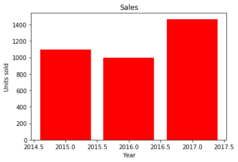

```python
import numpy.matlib
import numpy as np
from matplotlib import pyplot as plt  #Plotting lib for python
x = [2015,2016,2017]
y = [1098,1000,1466]


plt.bar(x, y,color='r',align = 'center')

plt.title('Sales')
plt.ylabel('Units sold')
plt.xlabel('Year')

plt.show()
```

# Scipy

SciPy is a collection of mathematical algorithms and convience functions build on Numpy data structures. subpackages are well organized such that they cover different scientific computing areas. we use the following code to import any particular sub-package, :-

```python
#from scipy import some_module
#some_module.some_function()
##INDEX TRICKS:-
# We can use the operation of np.mgrid , np.ogrid , np.r_ , and np.c_ for quickly constructing arrays.
from scipy import linalg, optimize
#For example, rather than writing something like the following
mul = np.concatenate(([4], [0]*8, np.arange(-1, 1.002, 2/9.0)))
print(mul)
#with the r_ command one can enter this as
m2 = np.r_[4,[0]*8,-1:1:10j]
print(m2)
##creating arrays
print("arrays:")
print(np.mgrid[2:7,0:2])      #creates 2 arrays within the given range
##concatenation objects to form an array
print("concatenating objects into an array")
print(np.r_[19,2,2:8,0:3])
```

```
[ 4.          0.          0.          0.          0.          0.          0.
  0.          0.         -1.         -0.77777778 -0.55555556 -0.33333333
 -0.11111111  0.11111111  0.33333333  0.55555556  0.77777778  1.        ]
[ 4.          0.          0.          0.          0.          0.          0.
  0.          0.         -1.         -0.77777778 -0.55555556 -0.33333333
 -0.11111111  0.11111111  0.33333333  0.55555556  0.77777778  1.        ]
arrays:
[[[2 2]
  [3 3]
  [4 4]
  [5 5]
  [6 6]]

 [[0 1]
  [0 1]
  [0 1]
  [0 1]
  [0 1]]]
concatenating objects into an array
[19  2  2  3  4  5  6  7  0  1  2]
```

```python
## giving a datatype to an array
print("the float is")
print(np.cast['f'](11))#f means the no is float
print("Integer is")
print(np.cast['i'](13.0))
##Polynomials
from numpy import poly1d   #importing library
x=poly1d([14,28,54,98])
print("creating polynomials: ")
print(x)
```

```
the float is
11.0
Integer is
13
creating polynomials:
    3      2
14 x + 28 x + 54 x + 98
```

```python
##Linear algebra
#scipy.linalg contains all the functions in numpy.linalg. plus some other more advanced ones not contained in numpy.linalg
import scipy.linalg
# Inverse of a matrix:
mat = np.random.rand(2,2)
print("random matrix 2x2")
print(mat)
#creating a random 2x2 matrix using the NumPy random function
print("inverse of a matrix:")
print(scipy.linalg.inv(mat))
#this will give us the inverse of the matrix

#Eigen values
ev = np.random.rand(4,4)
print("random matrix 4x4")
print(ev)
#random matrix created using numpy random functions
print("Eigen values:")
print(scipy.linalg.eigvals(ev))
#This will give us the eigen values of the above randomized matrix

#Finding Determinant
print("Finding the determinant")
det = np.array([[2,4],[6,8]]) #we create a 2x2 matrix
print("the created matrix is")
print(det)
print(linalg.det(det))
#will print the matrix determinant

import scipy.integrate

# General Integration
#The function quad is provided to integrate a function of one variable between two points.
ans, err = scipy.integrate.quad(lambda x: x**3,0.,4)
print("general integration: ")
print(ans)
```

```
random matrix 2x2
[[ 0.80973295  0.0406729 ]
 [ 0.41964333  0.59619685]]
inverse of a matrix:
[[ 1.28023821 -0.0873386 ]
 [-0.90111753  1.73877313]]
random matrix 4x4
[[ 0.20740788  0.40453293  0.68775625  0.48444388]
 [ 0.22753108  0.92613798  0.69389849  0.75928349]
 [ 0.42048509  0.37766507  0.33845955  0.25718969]
 [ 0.73740843  0.63661115  0.86572381  0.15045242]]
Eigen values:
[ 2.03407118+0.j  0.24768744+0.j -0.46177285+0.j -0.19752793+0.j]
Finding the determinant
the created matrix is
[[2 4]
 [6 8]]
-8.0
general integration:
64.0
```

# References

https://www.tutorialspoint.com/numpy/numpy_matplotlib.htm

https://docs.scipy.org/doc/scipy/reference/linalg.interpolative.html#module-scipy.linalg.interpolative

https://datacamp.com